# Bellabeat_Case-study

San

2025-09-15

# **Scenario**

This case study is about Bellabeat, a high-tech manufacturer of health-focused smart devices for women. The company has the potential to expand its presence in the global smart device market. Urška Sršen, Bellabeat’s cofounder and Chief Creative Officer, believes that analyzing smart device fitness data can reveal new growth opportunities. The marketing team has therefore decided to investigate how consumers use smart devices in order to uncover usage trends and generate insights. The goal is to apply these findings to one of Bellabeat’s products and develop high-level recommendations that can inform Bellabeat’s marketing strategy.

# **Business Task**

Question

- What are some trends in sma device usage?
- How could these trends apply to Bellabeat customers?
- How could these trends help inuence Bellabeat marketing strateg

Business task : analyze Fitbit smart device data to identify usage trends and apply these insights to Bellabeat’s products.

Primary stakeholders: Sando Mur, Mathematician and Bellabeat’s cofounder; key member of the Bellabeat executive team

Secondary stakeholders: Bellabeat marketing analytics team

# **Data Prepare**

The dataset includes:

- Minute-level output for physical activity, heart rate, and sleep monitoring
- Daily-level data such as activity (steps, active minutes), calories burned, and sleep patterns

This dataset provides valuable insights into users’ daily habits and can be leveraged to identify trends in smart device usage that may be applied to Bellabeat’s customer base.

For this analysis, only three files will be used: daily activity, sleep, and heart rate. Note that the heart rate data is limited, as it only includes 18 users.

The first step is to load all the packages required for the analysis:

```r
library(tidyverse)
library(lubridate)
library(janitor)
```

```r
library(ggplot2)
```

## Load Dataset

These three files will allow us to analyze users’ daily activity, sleep behavior, and heart rate patterns, which can provide insights into overall health and lifestyle habits.

```r
daily_activity <- read.csv("dailyActivity_merged.csv")
sleep <- read.csv("minuteSleep_merged.csv")
heartrate <- read.csv("heartrate_seconds_merged.csv")

head(daily_activity)
```

```
##           Id ActivityDate TotalSteps TotalDistance TrackerDistance
## 1 1503960366    4/12/2016      13162          8.50            8.50
## 2 1503960366    4/13/2016      10735          6.97            6.97
## 3 1503960366    4/14/2016      10460          6.74            6.74
## 4 1503960366    4/15/2016       9762          6.28            6.28
## 5 1503960366    4/16/2016      12669          8.16            8.16
## 6 1503960366    4/17/2016       9705          6.48            6.48
##   LoggedActivitiesDistance VeryActiveDistance ModeratelyActiveDistance
## 1                        0               1.88                     0.55
## 2                        0               1.57                     0.69
## 3                        0               2.44                     0.40
## 4                        0               2.14                     1.26
## 5                        0               2.71                     0.41
## 6                        0               3.19                     0.78
##   LightActiveDistance SedentaryActiveDistance VeryActiveMinutes
## 1                6.06                       0                25
## 2                4.71                       0                21
## 3                3.91                       0                30
## 4                2.83                       0                29
## 5                5.04                       0                36
## 6                2.51                       0                38
##   FairlyActiveMinutes LightlyActiveMinutes SedentaryMinutes Calories
## 1                  13                  328              728     1985
## 2                  19                  217              776     1797
## 3                  11                  181             1218     1776
## 4                  34                  209              726     1745
## 5                  10                  221              773     1863
## 6                  20                  164              539     1728
```

```r
head(sleep)
```

```
##           Id                 date value       logId
## 1 1503960366 4/12/2016 2:47:30 AM     3 11380564589
## 2 1503960366 4/12/2016 2:48:30 AM     2 11380564589
## 3 1503960366 4/12/2016 2:49:30 AM     1 11380564589
## 4 1503960366 4/12/2016 2:50:30 AM     1 11380564589
## 5 1503960366 4/12/2016 2:51:30 AM     1 11380564589
## 6 1503960366 4/12/2016 2:52:30 AM     1 11380564589
```

```r
head(heartrate)
```

```
##           Id                 Time Value
## 1 2022484408 4/12/2016 7:21:00 AM    97
## 2 2022484408 4/12/2016 7:21:05 AM   102
## 3 2022484408 4/12/2016 7:21:10 AM   105
## 4 2022484408 4/12/2016 7:21:20 AM   103
## 5 2022484408 4/12/2016 7:21:25 AM   101
## 6 2022484408 4/12/2016 7:22:05 AM    95
```

# **Data Process & Data Analyst**

Before analysis, cleaning and formatting the data tables is a must to ensure accuracy and consistency. In this step, we combined three different datasets — daily activity, sleep, and heart rate — into a single comprehensive table to support deeper analysis.

The following steps were performed:

```r
daily_activity_clean <- daily_activity %>%
  clean_names() %>%
  mutate(
    id = as.character(id),
    date = as.Date(activity_date, format = "%m/%d/%Y"),
    active_minutes = very_active_minutes + fairly_active_minutes,
    day_name = weekdays(date),
    day_type = case_when(wday(date) %in% c(1, 7) ~ "weekend",
                         TRUE ~ "weekday")
  ) %>%
  select(id,
         total_steps,
         active_minutes,
         date,
         day_type,
         day_name,
         calories) %>%
  distinct() %>%
  drop_na()
head(daily_activity_clean)
```

```
##           id total_steps active_minutes       date day_type  day_name calories
## 1 1503960366       13162             38 2016-04-12  weekday   Tuesday     1985
## 2 1503960366       10735             40 2016-04-13  weekday Wednesday     1797
## 3 1503960366       10460             41 2016-04-14  weekday  Thursday     1776
## 4 1503960366        9762             63 2016-04-15  weekday    Friday     1745
## 5 1503960366       12669             46 2016-04-16  weekend  Saturday     1863
## 6 1503960366        9705             58 2016-04-17  weekend    Sunday     1728
```

```r
sleep_clean <- sleep %>%
  clean_names() %>%
  mutate(
    id = as.character(id),
    datetime = mdy_hms(date),
    date = as_date(datetime),
    time = format(datetime, "%H:%M:%S")
  ) %>%
  select(
    id,
    date,
    time,
    log_id
  ) %>%
  drop_na() %>%
  distinct()
head(sleep_clean)
```

```
##           id       date     time      log_id
## 1 1503960366 2016-04-12 02:47:30 11380564589
## 2 1503960366 2016-04-12 02:48:30 11380564589
## 3 1503960366 2016-04-12 02:49:30 11380564589
## 4 1503960366 2016-04-12 02:50:30 11380564589
## 5 1503960366 2016-04-12 02:51:30 11380564589
## 6 1503960366 2016-04-12 02:52:30 11380564589
```

```r
heartrate_clean <- heartrate %>%
  clean_names() %>%
  mutate(
    id = as.character(id),
    datetime = mdy_hms(time),
    date = as_date(datetime)
  ) %>%
  drop_na() %>%
  select(
    id,
    date,
    value
  )
head(heartrate_clean)
```

```
##           id       date value
## 1 2022484408 2016-04-12    97
## 2 2022484408 2016-04-12   102
## 3 2022484408 2016-04-12   105
## 4 2022484408 2016-04-12   103
## 5 2022484408 2016-04-12   101
## 6 2022484408 2016-04-12    95
```

```r
sleep_daily <- sleep_clean %>%
  group_by(id, date) %>%
  summarise(
    total_sleep_minutes = n(),
    sleep_sessions = n_distinct(log_id), .groups = "drop"
  )

heartrate_daily <- heartrate_clean %>%
  group_by(id, date) %>%
  summarise(
    avg_heartrate = mean(value, na.rm = TRUE),
    max_heartrate = max(value, na.rm = TRUE),
    min_heartrate = min(value, na.rm = TRUE), .groups = "drop"
  )
head(sleep_daily)
```

```
## # A tibble: 6 × 4
##   id         date       total_sleep_minutes sleep_sessions
##   <chr>      <date>                   <int>          <int>
## 1 1503960366 2016-04-12                 346              1
## 2 1503960366 2016-04-13                 407              2
## 3 1503960366 2016-04-15                 442              1
## 4 1503960366 2016-04-16                 400              3
## 5 1503960366 2016-04-17                 679              1
## 6 1503960366 2016-04-19                 320              1
```

```r
head(heartrate_daily)
```

```
## # A tibble: 6 × 5
##   id         date       avg_heartrate max_heartrate min_heartrate
##   <chr>      <date>             <dbl>         <int>         <int>
## 1 2022484408 2016-04-12          75.8           134            52
## 2 2022484408 2016-04-13          80.3           156            51
## 3 2022484408 2016-04-14          72.6           127            50
## 4 2022484408 2016-04-15          80.4           189            53
## 5 2022484408 2016-04-16          76.0           136            49
## 6 2022484408 2016-04-17          83.9           161            52
```

These preprocessing steps are crucial to ensure high-quality insights in the next stages of exploration and visualization.

## **Data Merged**

In this step, we need to merged and enhanced three datasets — daily_activity_clean, sleep_daily, and heartrate_daily — to create a comprehensive dataset for exploration :

```r
daily_merged <- daily_activity_clean %>%
  left_join(sleep_daily, by = c("id", "date")) %>%
  left_join(heartrate_daily, by = c("id", "date"))
```

We performed a left join of all three datasets to the daily_activity_clean table using both id and date as keys. This approach ensures that every record from daily_activity_clean is retained while incorporating the corresponding information from the sleep_daily and heartrate_daily tables. By joining on matching id and date, we were able to consolidate activity, sleep, and heart rate data into a single dataset

```r
daily_merged$avg_heartrate <- as.numeric(
  ifelse(daily_merged$avg_heartrate == "Not Recorded", NA, daily_merged$avg_heartrate)
)
```

and we need to replaces “Not Recorded” with NA and converts the avg_heartrate column into numeric values for plotting

```r
daily_merged <- daily_merged %>%
  mutate(
    steps_category = case_when(
      total_steps < 5000 ~ "Sedentary",
      total_steps >= 5000 & total_steps <= 10000 ~ "Moderate",
      total_steps > 10000 ~ "Active"
    )
  ) %>%
  select(id, total_steps, steps_category, active_minutes, date, day_type, day_name, calories, total_sleep_minutes, sleep_sessions, avg_heartrate, max_heartrate, min_heartrate)
```

This code creates a new variable called steps_category to classify participants based on their daily step count. The classification is divided into three categories:

- Sedentary: less than 5,000 steps
- Moderate: between 5,000 and 10,000 steps
- Active: more than 10,000 steps

```r
head(daily_merged)
```

```
##           id total_steps steps_category active_minutes       date day_type
## 1 1503960366       13162         Active             38 2016-04-12  weekday
## 2 1503960366       10735         Active             40 2016-04-13  weekday
## 3 1503960366       10460         Active             41 2016-04-14  weekday
## 4 1503960366        9762       Moderate             63 2016-04-15  weekday
## 5 1503960366       12669         Active             46 2016-04-16  weekend
## 6 1503960366        9705       Moderate             58 2016-04-17  weekend
##    day_name calories total_sleep_minutes sleep_sessions avg_heartrate
## 1   Tuesday     1985                 346              1            NA
## 2 Wednesday     1797                 407              2            NA
## 3  Thursday     1776                  NA             NA            NA
## 4    Friday     1745                 442              1            NA
## 5  Saturday     1863                 400              3            NA
## 6    Sunday     1728                 679              1            NA
##   max_heartrate min_heartrate
## 1            NA            NA
## 2            NA            NA
## 3            NA            NA
## 4            NA            NA
## 5            NA            NA
## 6            NA            NA
```

```r
n_distinct(daily_merged$id)
```

```
## [1] 33
```

```r
nrow(daily_merged)
```

```
## [1] 940
```

```r
avg_steps <- daily_merged %>%
  summarise(
    Average_Steps = mean(total_steps, na.rm = TRUE)
  )
avg_steps
```

```
##   Average_Steps
## 1      7637.911
```

The final dataset contains 33 unique users and 940 rows. Each row represents a user’s daily record with information on steps, activity level, sleep, calories, and heart rate.

# **Data Plotting**

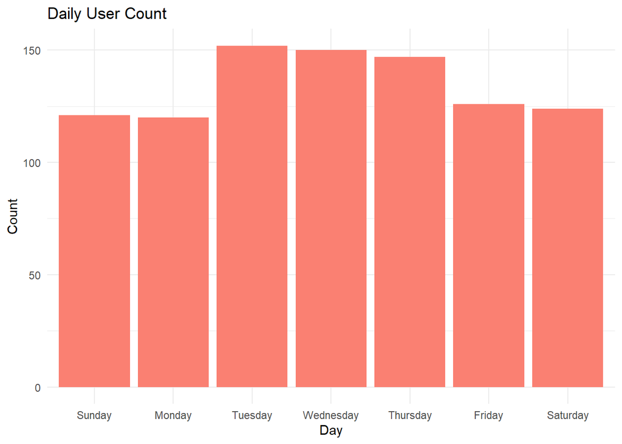

```r
user_days <- daily_merged %>%
  group_by(day_name) %>%
  summarise(total_users = n()) %>%
  mutate(day_name = factor(
    day_name,
    levels = c("Sunday","Monday","Tuesday","Wednesday","Thursday", "Friday", "Saturday")))

ggplot(user_days, aes(x = day_name, y = total_users)) +
  geom_col(fill = "#FA8072") +
  labs(title = "Daily User Count",
       x = "Day",
       y = "Count") +
  theme_minimal()
```

Daily User Count : User activity is highest on Tuesday and Wednesday, while Sunday and Monday have the lowest counts

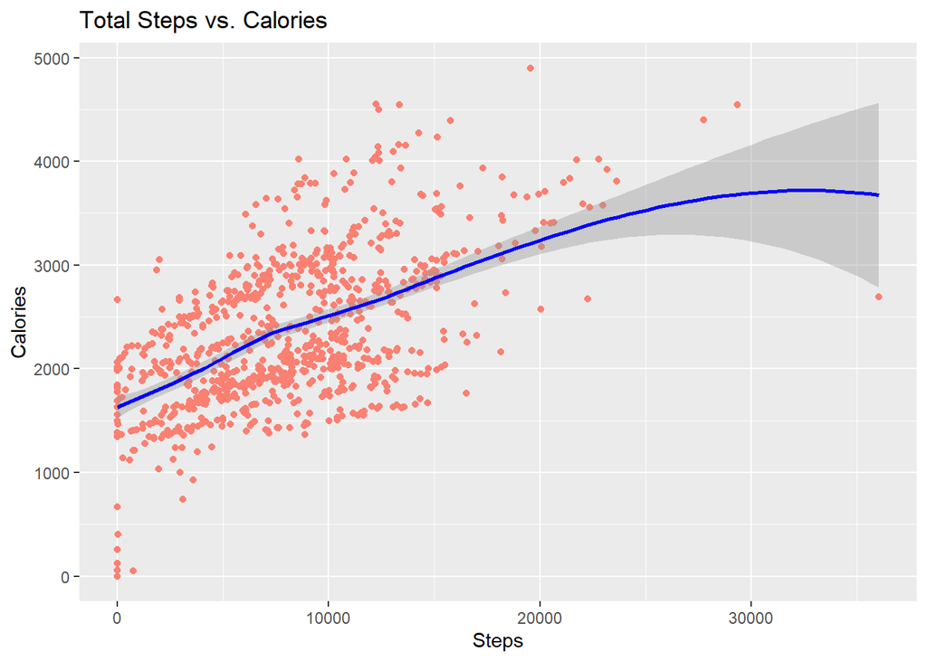

```r
ggplot(data = daily_merged, aes(x = total_steps, y = calories)) +
  geom_point(color = "#FA8072") +
  geom_smooth(color = "blue") +
  labs(title = "Total Steps vs. Calories",
       x = "Steps",
       y = "Calories")
```

Total steps vs calories : There is a clear positive correlation, meaning that as the number of steps increases, the calories burned also tend to increase

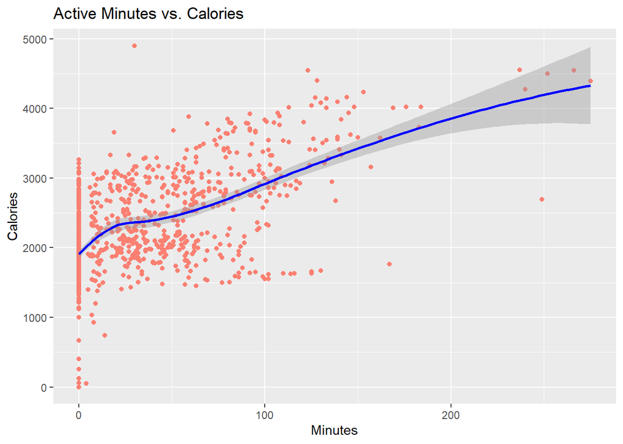

```r
ggplot(data = daily_merged, aes(x = active_minutes, y = calories)) +
  geom_point(color = "#FA8072") +
  geom_smooth(color = "blue") +
  labs(title = "Active Minutes vs. Calories",
       x = "Minutes",
       y = "Calories")
```

Active minutes vs calories : The upward trend indicates a positive correlation, the more active minutes a user has, the more calories they tend to burn

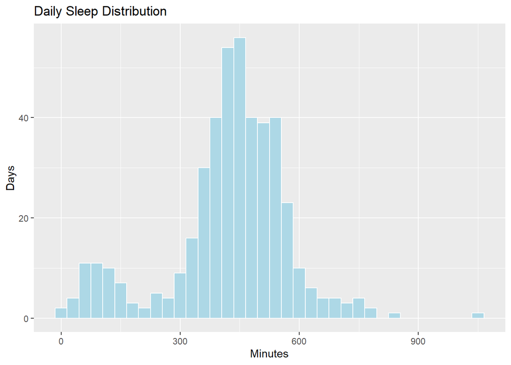

```r
ggplot(daily_merged, aes(x=total_sleep_minutes)) +
  geom_histogram(binwidth = 30, fill = "lightblue", color = "white", na.rm = TRUE) +
  labs(title = "Daily Sleep Distribution", x = "Minutes", y = "Days")
```

Daily Sleep Distribution : Most users sleep between 300 to 500 minutes (5–8 hours) per day